# PSY 5939: Longitudinal Data Analysis

# 1 Introduction

# 1.1 Growth model + latent class = ???

# 1.1.1 Variability in trajectories

We have talked about **predictors** of trajectories

- Girls have one average trajectory for alcohol use
- Boys have a different average trajectory for alcohol use

Here, gender is an **observed** variable

What if there is some categorical variable that predicts trajectories, but **you don’t actually observe it?**

- This predictor is **latent** or unobserved
- It may be a single unobserved variable
- More typically, it’s a pattern across multiple variables

# 1.1.2 Growth mixture models

Growth mixture models combine two different types of analysis:

1. Latent *growth* models: You know about these
2. Latent *class* analysis (also called mixture model): You probably don’t know about these

Allow different **latent** groups to have different trajectories

- This is *like* having predictors of growth, but the predictor is latent (unobserved)

# 2 Latent class analysis

# 2.1 Latent class analysis

# 2.1.1 Latent class analysis

Latent class = unknown / unobserved subgroups

- Here, “class” is used to mean groups

LCA is a latent variable technique that **classifies** people into previously unknown subgroups based on their responses to a set of variables

(Strictly speaking, LCA = categorical variables; latent profile analysis (LPA) is the term for this model with continuous variables)

People have different *patterns of responses* that define the different classes

- Not a single value on a single variable
- For example, people in group 1 are high on items 1-3, low on items 4-6
- People in group 2 are low on items 1-2 and high on items 3-6

# 2.1.2 What it looks like

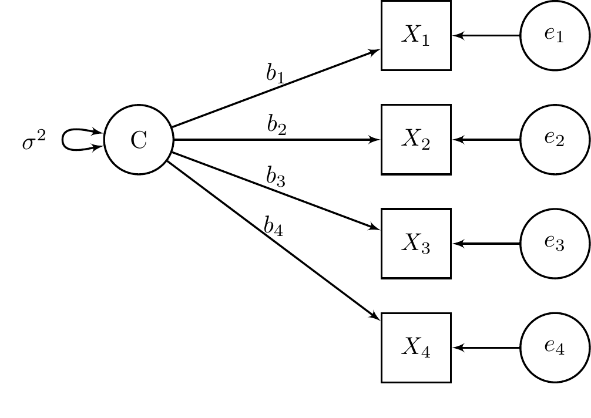

- Latent class (C) is **categorical**
  - Typically only nominal, not ordinal
- $X_1$ through $X_4$ are called **indicators** of the latent class
- Note that the latent variable **causes** the indicator values

# 2.1.3 LCA vs other methods

LCA is similar to other methods, goes by other names  
Help you contextualize what is going on in LCA

1. Factor analysis / measurement model  
   Very similar, but latent factor is continuous while *latent class is categorical*
2. Mixture model  
   Population is a “mixture” of subgroups, LCA “unmixes” them
3. Data reduction  
   Large number of items $\rightarrow$ smaller number of classes
4. Person-oriented approach  
   How do **people** have different *patterns*, rather than how are the **variables** related to one another for all *people*

# 2.1.4 Selecting the number of classes

We have some number of patterns (classes)?

- How do we decide how many?

Similar to exploratory factor analysis (EFA) methods

Run several models with different numbers of classes  
e.g., 1 class, 2 classes, 3 classes, etc.

Compare these models in terms of **model fit** and **theory**

Choose the model that has the **best fit** and **makes the most sense**

# 2.1.5 Model fit for LCA

- **Chi-square test**  
  Problematic for large samples, do not rely on it
- **Likelihood ratio test** (also bootstrap LR test)  
  Same as previous LR tests, compare two models
- **AIC and BIC**  
  Smaller is better, not a measure of absolute fit
- **Entropy** - certainty of classification  
  Ranges from 0 to 1, closer to 1 is better
- **Predicted vs observed means / probabilities**  
  Mean for each item within each class - do they match

BIC and LR test are best for choosing the number of classes

- AIC and entropy are bad for choosing the correct number of classes
- You can report AIC and entropy – they tell you about the model – but don’t use them to decide on the number of classes

# 2.1.6 Mplus example 7.9 (modified)

4 continuous indicators, 2 classes

```r
DATA:
FILE IS ex7.9.dat;

VARIABLE:
NAMES ARE y1-y4 x;
USEVARIABLES ARE y1-y4;
CLASSES = c (2);

ANALYSIS:
TYPE = MIXTURE;

PLOT:
TYPE=PLOT3;
SERIES = y1(1) y2(2) y3(3) y4(4);
```

# 2.1.7 Model-implied response pattern

```r
MODEL RESULTS

                                                    Two-Tailed
                    Estimate       S.E.  Est./S.E.    P-Value

Latent Class 1

 Means
    Y1                -1.056      0.070    -15.030      0.000
    Y2                -1.088      0.067    -16.255      0.000
    Y3                -0.943      0.063    -15.050      0.000
    Y4                -1.093      0.074    -14.688      0.000

...

Latent Class 2

 Means
    Y1                 1.037      0.070     14.762      0.000
    Y2                 1.004      0.064     15.682      0.000
    Y3                 0.865      0.068     12.763      0.000
    Y4                 0.980      0.060     16.321      0.000

...
```

# 2.1.8 Model-implied response pattern

GRAPH $\rightarrow$ VIEW GRAPHS $\rightarrow$ ESTIMATED MEANS (Windows only)

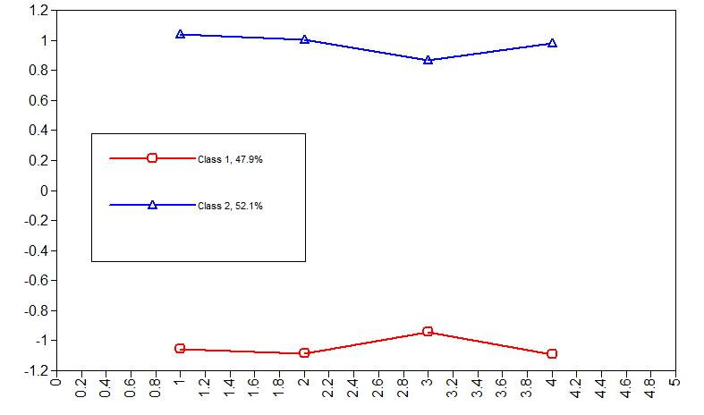

# 2.1.9 Model-implied response pattern

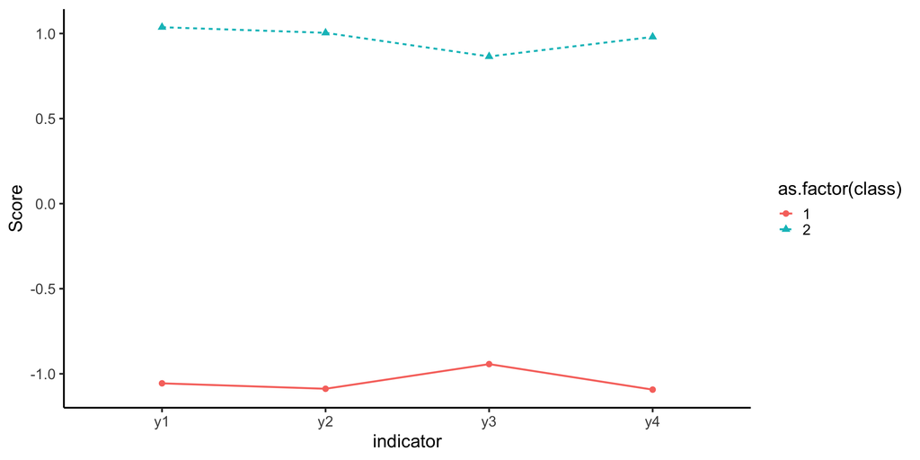

# 2.1.10 Another example

Quaiser-Pohl, Geiser, & Lehmann (2006)  
3 classes with binary indicators  
How often do you play the following types of computer games?  
Never or rarely (0) vs. Often or very often (1)

1. Adventure
2. Action
3. Sport
4. Fantasy role playing
5. Logic
6. Skill training
7. Simulation
8. Driving simulation

# 2.1.11 Mplus syntax

```r
DATA: FILE = computer_games.dat;

VARIABLE: NAMES = gender c1-c8;
          USEVARIABLES = c1-c8;
          CATEGORICAL = c1-c8;
          CLASSES = L(3);

ANALYSIS: TYPE = MIXTURE;

PLOT:   TYPE = PLOT3;
        SERIES = c1(1) c2(2) c3(3) c4(4)
                 c5(5) c6(6) c7(7) c8(8);

SAVEDATA: FILE = computer_games_3_classes.dat;
          SAVE = CPROBABILITIES;
```

# 2.1.12 Model-implied response pattern

```r
MODEL RESULTS

                                                    Two-Tailed
                    Estimate       S.E.  Est./S.E.    P-Value

Latent Class 1

 Thresholds
    C1$1               0.555      0.144      3.852      0.000
    C2$1              -0.591      0.191     -3.101      0.002
    C3$1              -0.097      0.163     -0.593      0.553
    C4$1               0.463      0.143      3.244      0.001
    C5$1               1.154      0.247      4.680      0.000
    C6$1               1.542      0.291      5.290      0.000
    C7$1              -0.628      0.152     -4.134      0.000
    C8$1              -0.576      0.159     -3.633      0.000

Latent Class 2

 Thresholds
    C1$1               1.398      0.506      2.761      0.006
    C2$1               1.920      0.706      2.717      0.007
    C3$1               1.675      0.423      3.961      0.000
    C4$1               1.489      0.523      2.850      0.004
    C5$1              -0.981      0.406     -2.413      0.016
    C6$1              -1.480      0.654     -2.263      0.024
    C7$1               0.187      0.357      0.524      0.600
    C8$1               0.685      0.334      2.052      0.040

Latent Class 3

 Thresholds
    C1$1               4.582      0.780      5.872      0.000
    C2$1               4.334      0.804      5.388      0.000
    C3$1               2.723      0.322      8.455      0.000
    C4$1               4.583      0.927      4.947      0.000
    C5$1               2.216      0.300      7.391      0.000
    C6$1               2.166      0.366      5.924      0.000
    C7$1               2.873      0.326      8.817      0.000
    C8$1               2.845      0.410      6.937      0.000

...

RESULTS IN PROBABILITY SCALE

Latent Class 1

 C1
    Category 1         0.635      0.033     19.021      0.000
    Category 2         0.365      0.033     10.915      0.000
 C2
    Category 1         0.356      0.044      8.152      0.000
    Category 2         0.644      0.044     14.721      0.000
 C3
    Category 1         0.476      0.041     11.727      0.000
    Category 2         0.524      0.041     12.916      0.000
 C4
    Category 1         0.614      0.034     18.144      0.000
    Category 2         0.386      0.034     11.423      0.000
 C5
    Category 1         0.760      0.045     16.915      0.000
    Category 2         0.240      0.045      5.332      0.000
 C6
    Category 1         0.824      0.042     19.465      0.000
    Category 2         0.176      0.042      4.165      0.000
 C7
    Category 1         0.348      0.034     10.094      0.000
    Category 2         0.652      0.034     18.917      0.000
 C8
    Category 1         0.360      0.037      9.847      0.000
    Category 2         0.640      0.037     17.521      0.000

Latent Class 2

 C1
    Category 1         0.802      0.080      9.967      0.000
    Category 2         0.198      0.080      2.463      0.014
 C2
    Category 1         0.872      0.079     11.068      0.000
    Category 2         0.128      0.079      1.623      0.105
 C3
    Category 1         0.842      0.056     14.991      0.000
    Category 2         0.158      0.056      2.808      0.005
 C4
    Category 1         0.816      0.078     10.399      0.000
    Category 2         0.184      0.078      2.345      0.019
 C5
    Category 1         0.273      0.081      3.383      0.001
    Category 2         0.727      0.081      9.020      0.000
 C6
    Category 1         0.185      0.099      1.877      0.060
    Category 2         0.815      0.099      8.247      0.000
 C7
    Category 1         0.547      0.088      6.179      0.000
    Category 2         0.453      0.088      5.125      0.000
 C8
    Category 1         0.665      0.074      8.941      0.000
    Category 2         0.335      0.074      4.508      0.000

Latent Class 3

 C1
    Category 1         0.990      0.008    126.531      0.000
    Category 2         0.010      0.008      1.295      0.195
 C2
    Category 1         0.987      0.010     96.062      0.000
    Category 2         0.013      0.010      1.259      0.208
 C3
    Category 1         0.938      0.019     50.383      0.000
    Category 2         0.062      0.019      3.309      0.001
 C4
    Category 1         0.990      0.009    106.680      0.000
    Category 2         0.010      0.009      1.090      0.276
 C5
    Category 1         0.902      0.027     33.919      0.000
    Category 2         0.098      0.027      3.699      0.000
 C6
    Category 1         0.897      0.034     26.596      0.000
    Category 2         0.103      0.034      3.049      0.002
 C7
    Category 1         0.947      0.017     57.362      0.000
    Category 2         0.053      0.017      3.242      0.001
 C8
    Category 1         0.945      0.021     44.386      0.000
    Category 2         0.055      0.021      2.580      0.010
```

# 2.1.13 Model-implied response pattern

GRAPH $\rightarrow$ VIEW GRAPHS $\rightarrow$ ESTIMATED PROBABILITIES (Windows only)

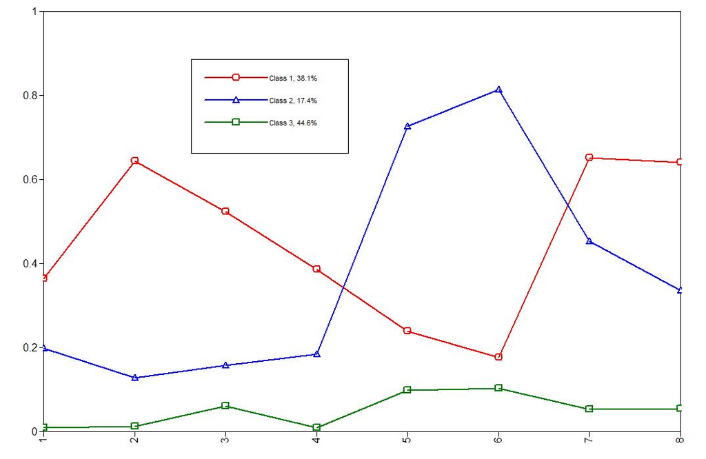

# 2.1.14 Model-implied response pattern

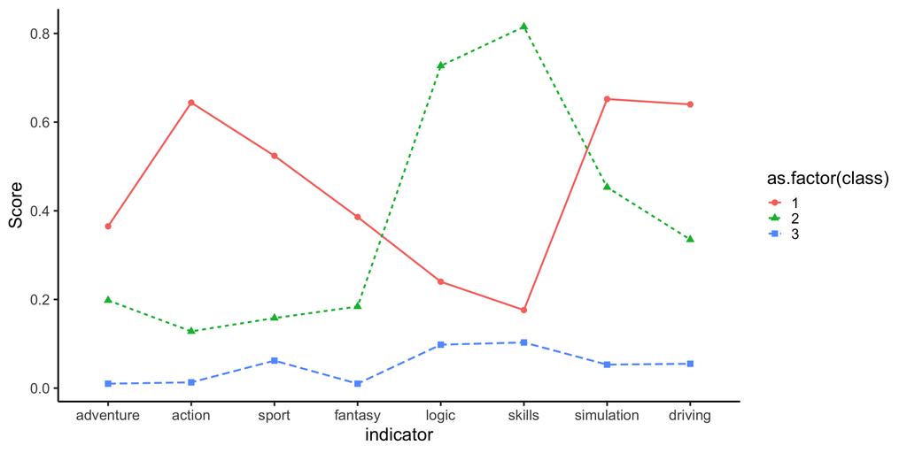

# 3 Growth mixture models

# 3.1 Growth mixture and latent class growth analysis

# 3.1.1 Growth mixture models

**Growth mixture models** use a latent class to predict growth

Previously:

We used an **observed** variable to predict growth trajectory

- Gender predicts trajectory $\rightarrow$ different predicted trajectory for boys versus girls

Now, we can use a **latent class** (unobserved, potentially multivariate construct) to predict growth trajectory

- Type of video game player

# 3.1.2 Growth mixture vs latent class growth analysis

There are two **slightly** different kinds of models that incorporate a latent class component in a growth modeling framework

- Growth mixture models (GMM)
- Latent class growth analysis (LCGA)

GMM allows **within-class variation** in growth trajectories

- People in the *same class* are allowed to vary in their intercepts and slopes

LCGA does not allow this, so any variation among people in the same class just becomes **error variance**

LCGA are more constrained, often used to explore the data  
I will refer to all these analyses as “growth mixture models”

# 3.1.3 Growth mixture model

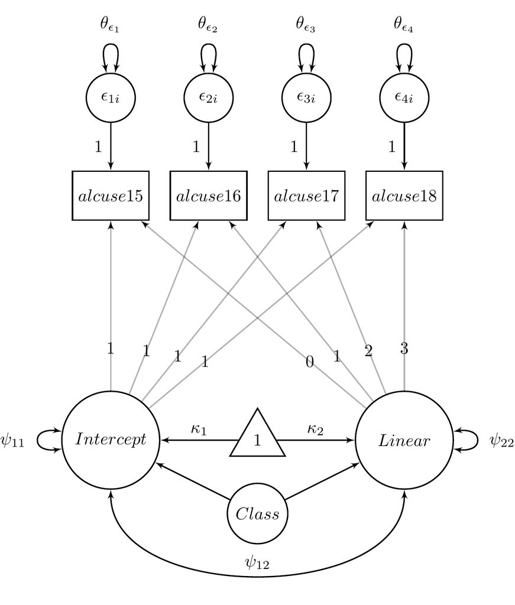

# 3.1.4 Latent class growth analysis

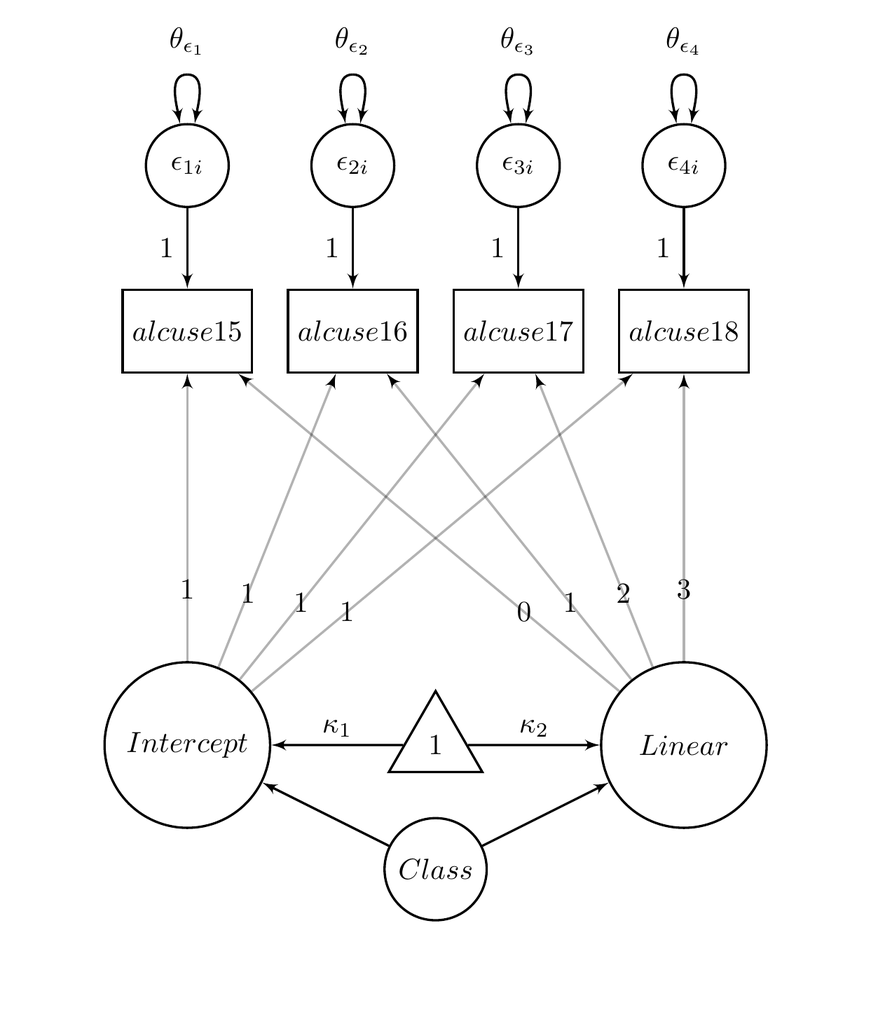

# 3.1.5 Running growth mixture models

As with LCA, running GMM is an iterative procedure

Run a 1 class model, a 2 class model, etc.

Compare these models in terms of model fit:

- BIC
- LR test
- Entropy (classification quality)
- Theoretical utility

# 3.1.6 Technical issues

Growth mixture models often need a lot of constraints

- May need to constrain parameters in some classes but not in others
- Frequently need to supply start values

These examples are all LCGA models  
$\rightarrow$ No within class variance components (all people in the **same class** have **same intercept and slope**)

- Intercept, linear trend, and quadratic trend means are estimated for all classes
- Intercept, linear trend, and quadratic trend *variance components* are **fixed at 0** for all classes
- Use previous model solution as start values for classes in next model (I’ll show you what this means)

# 3.2 LCGA example

# 3.2.1 Growth mixture / LCGA example

This is LCGA example  
(It is sometimes hard to get a true GMM to run)  
Example where we can look at 1, 2, 3, and 4 class solutions

Antisocial behavior at 4 time points  
Time is centered at first time point

Two major research questions:

1. How does antisocial behavior change over time?
2. Are there **subgroups** of people who have **different trajectories** in antisocial behavior?

# 3.2.2 One-class LCGA results

| Fit index | Value |
| --- | --- |
| # parameters | 4 |
| BIC | 5712.128 |

| Estimate | Class 1 |
| --- | --- |
| Intercept | 1.703* |
| Linear | 0.237* |
| Quadratic | -0.045 |
| Residual variance | 3.721* |
| Proportion | 1.00 |

# 3.2.3 One-class LCGA results

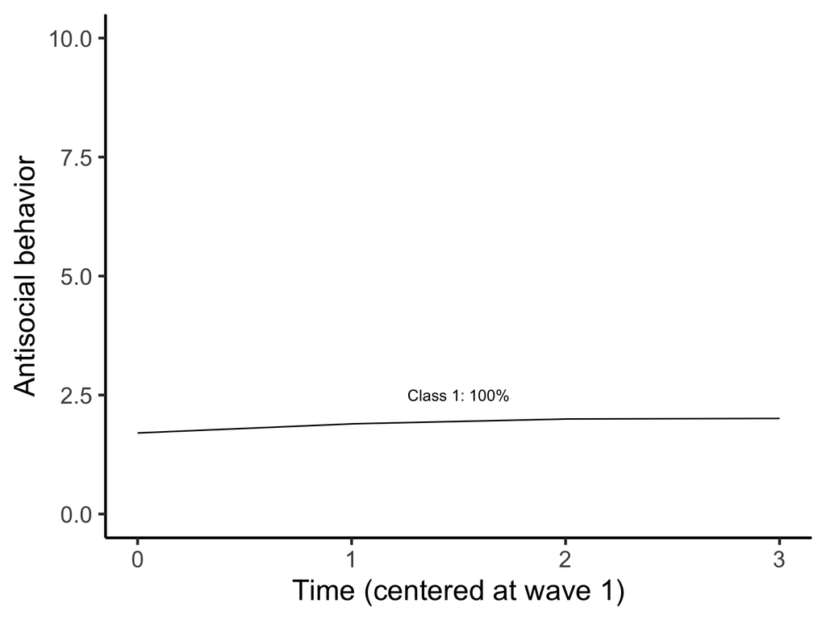

# 3.2.4 Two-class LCGA results

| Fit index | Value |
| --- | --- |
| # parameters | 8 |
| BIC | 5354.937 |
| LRT p-value | .0006 |

| Estimate | Class 1 | Class 2 |
| --- | --- | --- |
| Intercept | 3.304* | 1.211* |
| Linear | 1.018* | 0.014 |
| Quadratic | -0.170 | 0.001 |
| Residual variance | 2.188* | 2.188* |
| Proportion | 0.225 | 0.775 |

# 3.2.5 Two-class LCGA results

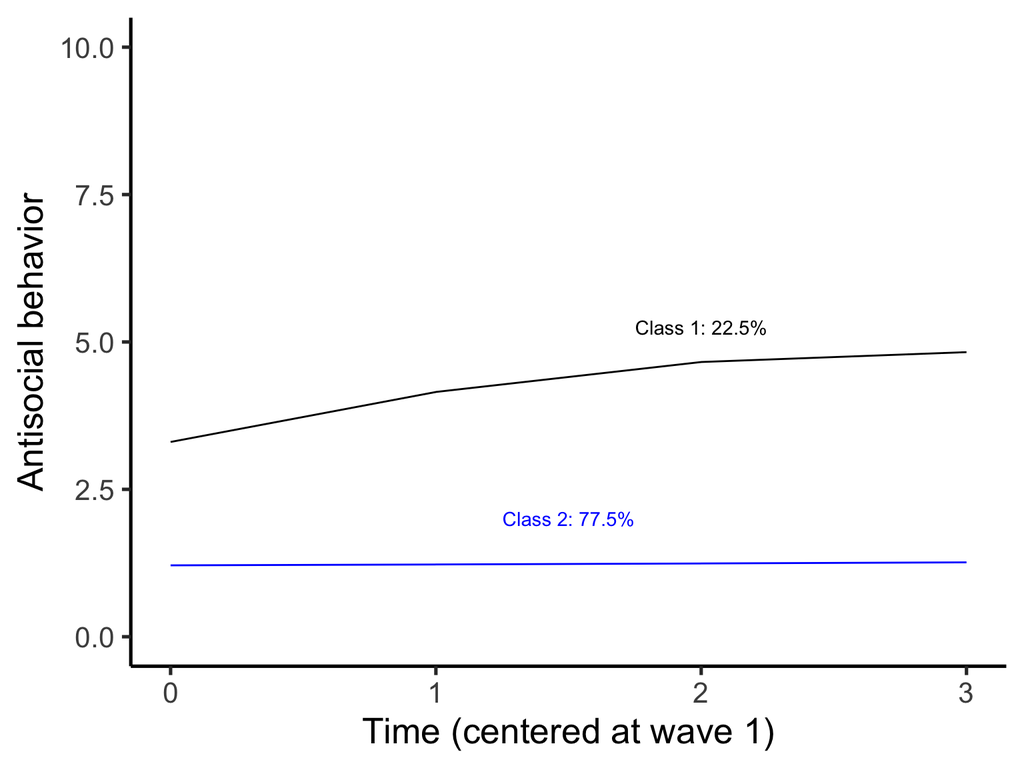

# 3.2.6 Three-class LCGA results

| Fit index | Value |
| --- | --- |
| # parameters | 12 |
| BIC | 5268.238 |
| LRT p-value | .0070 |

| Estimate | Class 1 | Class 2 | Class 3 |
| --- | --- | --- | --- |
| Intercept | 3.740* | 1.106* | 2.766* |
| Linear | 3.505* | 0.014 | 0.133 |
| Quadratic | -0.796* | -0.015 | 0.113 |
| Residual variance | 1.829* | 1.829* | 1.829* |
| Proportion | 0.062 | 0.711 | 0.227 |

# 3.2.7 Three-class LCGA results

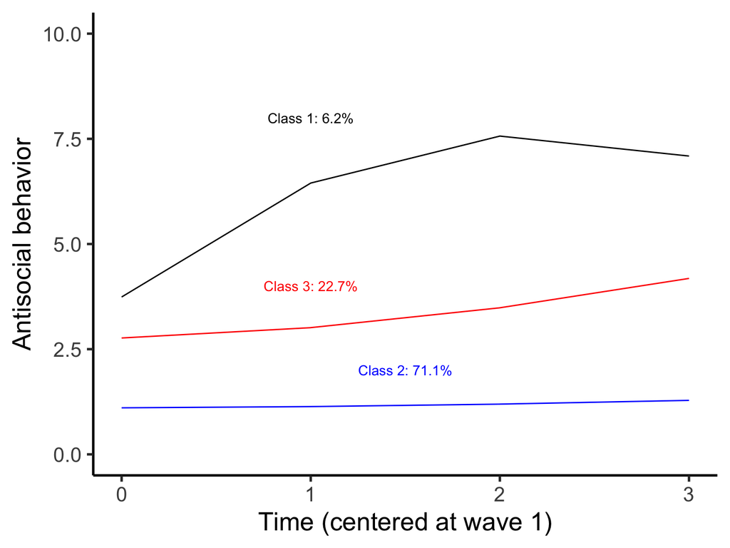

# 3.2.8 Four-class LCGA results

| Fit index | Value |
| --- | --- |
| # parameters | 16 |
| BIC | 5263.066 |
| LRT p-value | .2066 |

| Estimate | Class 1 | Class 2 | Class 3 | Class 4 |
| --- | --- | --- | --- | --- |
| Intercept | 5.111* | 1.102* | 3.154* | 2.336* |
| Linear | 0.033 | -0.003 | 4.190* | 0.146 |
| Quadratic | -0.120 | -0.017 | -0.928* | 0.149 |
| Residual variance | 1.715* | 1.715* | 1.715* | 1.715* |
| Proportion | 0.037 | 0.689 | 0.057 | 0.217 |

# 3.2.9 Four-class LCGA results

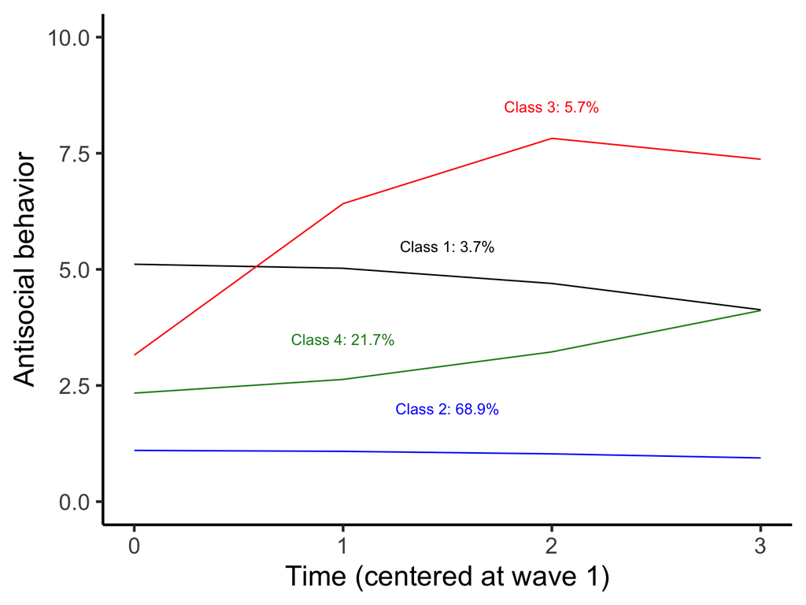

# 3.3 Evaluating the LCGA

# 3.3.1 BIC comparison - smaller is better

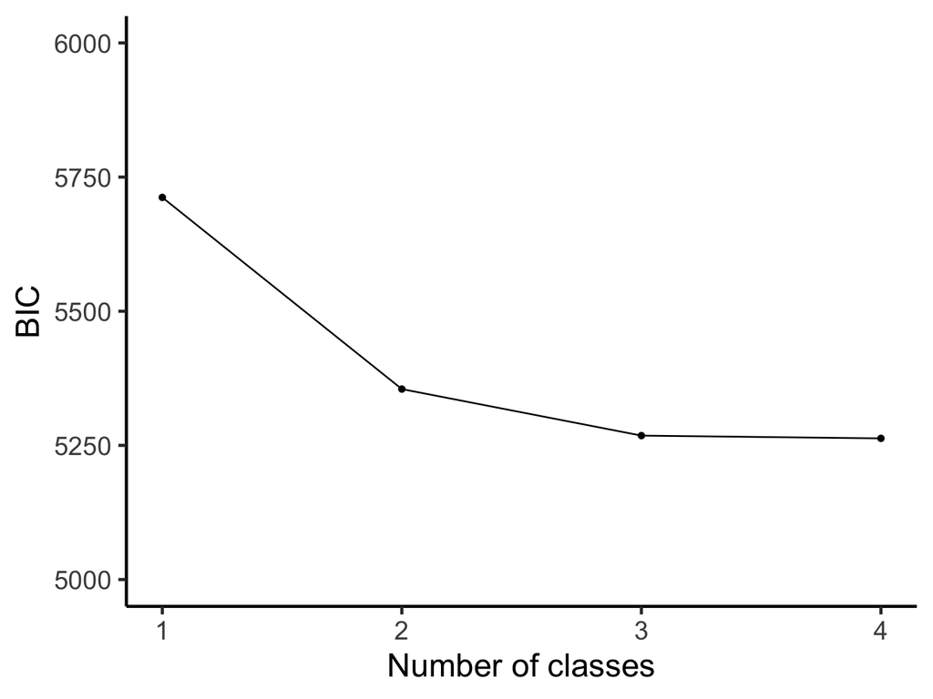

# 3.3.2 Likelihood ratio tests comparison

The likelihood ratio test (LRT) compares your model to a model with **1 fewer classes**

A significant result means that your model is better than the model with fewer classes

| Classes | LRT statistic | p-value | Conclusion |
| --- | --- | --- | --- |
| 1 | N/A | N/A | None |
| 2 | 26.826 | .0006 | 2 better than 1 |
| 3 | -9.646 | .0070 | 3 better than 2 |
| 4 | 15.268 | .2066 | 4 NOT better than 3 |

# 3.3.3 Classification quality

How *confident* are you of *classification*?

- Did people in class 1 also have a good chance of begin put in class 2?
1. Classification table
- k x k table, where k is the number of classes in the model
- Good classification = diagonals high, off-diagonals low
- A bit like reliability, “high” is greater than .80
2. Entropy  
   Ranges from 0 to 1, with higher values indicating better overall classification accuracy / confidence

# 3.3.4 Classification quality - 2 classes

Rows = Most likely class (class they are assigned to)

Columns = Average probability of class k membership

| . | 1 | 2 |
| --- | --- | --- |
| 1 | 0.909 | 0.091 |
| 2 | 0.033 | 0.967 |

Entropy = 0.840

# 3.3.5 Classification quality - 3 classes

Rows = Most likely class (class they are assigned to)

Columns = Average probability of class k membership

| . | 1 | 2 | 3 |
| --- | --- | --- | --- |
| 1 | 0.920 | 0.001 | 0.079 |
| 2 | 0.001 | 0.940 | 0.059 |
| 3 | 0.025 | 0.091 | 0.884 |

Entropy = 0.834

# 3.3.6 Classification quality - 4 classes

Rows = Most likely class (class they are assigned to)

Columns = Average probability of class k membership

| . | 1 | 2 | 3 | 4 |
| --- | --- | --- | --- | --- |
| 1 | 0.836 | 0.000 | 0.076 | 0.087 |
| 2 | 0.000 | 0.929 | 0.001 | 0.069 |
| 3 | 0.087 | 0.004 | 0.832 | 0.076 |
| 4 | 0.039 | 0.112 | 0.014 | 0.836 |

Entropy = 0.826

# 3.3.7 Summary of results from LCGA

LRT suggests 3 classes

Extra class in the 4 class solution is very small (4%) and not much different from another class  
4 class solution has 3 classes with no linear or quadratic slope: differ only for intercepts (and only slightly)  
Be wary of very small (<5%) classes: often unreliable but could also just be a rare group

# 3.3.8 Three class model input

```r
data:
file is 'antisocial_missing.txt';

variable:
names are
anti1 - anti4 read1 - read4
male momage kidage homecog homeemo id;
usevariables are anti1 - anti4;
missing are all (999);
classes = c(3);

analysis:
type is missing mixture;
coverage = .0000001;
iterations = 3000;

model:
%overall%
!quadratic growth model
icept linear quad | anti1@0 anti2@1 anti3@2 anti4@3;
! equal residual variances
anti1 - anti4 (1);
! FIX VARIANCE COMPONENTS TO ZERO FOR LCGA;
icept@0 linear@0 quad@0;
icept with linear@0 quad@0;
linear with quad@0;

%c#1%
[icept*3.304 linear*1.018 quad*-.17];
%c#2%
[icept*1.211 linear*.014 quad*.001];
%c#3%
[icept* linear* quad*];

output: tech11;
```

# 3.3.9 Three class model output 1

```r
THE MODEL ESTIMATION TERMINATED NORMALLY

MODEL FIT INFORMATION

Number of Free Parameters                       12

Loglikelihood

          H0 Value                       -2598.096
          H0 Scaling Correction Factor      1.5497
            for MLR

Information Criteria

          Akaike (AIC)                    5220.192
          Bayesian (BIC)                  5268.238
          Sample-Size Adjusted BIC        5230.161
            (n* = (n + 2) / 24)

FINAL CLASS COUNTS AND PROPORTIONS FOR THE LATENT CLASSES
BASED ON THE ESTIMATED MODEL

    Latent
   Classes

       1        100.44952          0.24802
       2        279.06685          0.68905
       3         25.48363          0.06292

FINAL CLASS COUNTS AND PROPORTIONS FOR THE LATENT CLASSES
BASED ON ESTIMATED POSTERIOR PROBABILITIES

    Latent
   Classes

       1        100.44952          0.24802
       2        279.06685          0.68905
       3         25.48363          0.06292

FINAL CLASS COUNTS AND PROPORTIONS FOR THE LATENT CLASSES
BASED ON THEIR MOST LIKELY LATENT CLASS MEMBERSHIP

Class Counts and Proportions

    Latent
   Classes

       1               92          0.22716
       2              288          0.71111
       3               25          0.06173

CLASSIFICATION QUALITY

     Entropy                         0.834

Average Latent Class Probabilities for Most Likely Latent Class Membership (Row)
by Latent Class (Column)

           1        2        3

    1   0.884    0.091    0.025
    2   0.059    0.940    0.001
    3   0.079    0.001    0.920

Classification Probabilities for the Most Likely Latent Class Membership (Column)
by Latent Class (Row)

           1        2        3

    1   0.810    0.170    0.020
    2   0.030    0.970    0.000
    3   0.089    0.009    0.902

Logits for the Classification Probabilities for the Most Likely Latent Class Membership (Column)
by Latent Class (Row)

              1        2        3

    1      3.722    2.163    0.000
    2      5.431    8.907    0.000
    3     -2.321   -4.607    0.000
```

# 3.3.10 Three class model output 2

```r
MODEL RESULTS

                                                    Two-Tailed
                    Estimate       S.E.  Est./S.E.    P-Value

Latent Class 1

 ICEPT    |
    ANTI1              1.000      0.000    999.000    999.000
    ANTI2              1.000      0.000    999.000    999.000
    ANTI3              1.000      0.000    999.000    999.000
    ANTI4              1.000      0.000    999.000    999.000

 LINEAR   |
    ANTI1              0.000      0.000    999.000    999.000
    ANTI2              1.000      0.000    999.000    999.000
    ANTI3              2.000      0.000    999.000    999.000
    ANTI4              3.000      0.000    999.000    999.000

 QUAD     |
    ANTI1              0.000      0.000    999.000    999.000
    ANTI2              1.000      0.000    999.000    999.000
    ANTI3              4.000      0.000    999.000    999.000
    ANTI4              9.000      0.000    999.000    999.000

 ICEPT    WITH
    LINEAR             0.000      0.000    999.000    999.000
    QUAD               0.000      0.000    999.000    999.000

 LINEAR   WITH
    QUAD               0.000      0.000    999.000    999.000

 Means
    ICEPT              2.766      0.231     11.964      0.000
    LINEAR             0.133      0.345      0.385      0.700
    QUAD               0.113      0.115      0.982      0.326

 Intercepts
    ANTI1              0.000      0.000    999.000    999.000
    ANTI2              0.000      0.000    999.000    999.000
    ANTI3              0.000      0.000    999.000    999.000
    ANTI4              0.000      0.000    999.000    999.000

 Variances
    ICEPT              0.000      0.000    999.000    999.000
    LINEAR             0.000      0.000    999.000    999.000
    QUAD               0.000      0.000    999.000    999.000

 Residual Variances
    ANTI1              1.829      0.102     17.935      0.000
    ANTI2              1.829      0.102     17.935      0.000
    ANTI3              1.829      0.102     17.935      0.000
    ANTI4              1.829      0.102     17.935      0.000

Latent Class 2

 ICEPT    |
    ANTI1              1.000      0.000    999.000    999.000
    ANTI2              1.000      0.000    999.000    999.000
    ANTI3              1.000      0.000    999.000    999.000
    ANTI4              1.000      0.000    999.000    999.000

 LINEAR   |
    ANTI1              0.000      0.000    999.000    999.000
    ANTI2              1.000      0.000    999.000    999.000
    ANTI3              2.000      0.000    999.000    999.000
    ANTI4              3.000      0.000    999.000    999.000

 QUAD     |
    ANTI1              0.000      0.000    999.000    999.000
    ANTI2              1.000      0.000    999.000    999.000
    ANTI3              4.000      0.000    999.000    999.000
    ANTI4              9.000      0.000    999.000    999.000

 ICEPT    WITH
    LINEAR             0.000      0.000    999.000    999.000
    QUAD               0.000      0.000    999.000    999.000

 LINEAR   WITH
    QUAD               0.000      0.000    999.000    999.000

 Means
    ICEPT              1.106      0.084     13.219      0.000
    LINEAR             0.014      0.113      0.121      0.904
    QUAD              -0.015      0.036     -0.420      0.675

 Intercepts
    ANTI1              0.000      0.000    999.000    999.000
    ANTI2              0.000      0.000    999.000    999.000
    ANTI3              0.000      0.000    999.000    999.000
    ANTI4              0.000      0.000    999.000    999.000

 Variances
    ICEPT              0.000      0.000    999.000    999.000
    LINEAR             0.000      0.000    999.000    999.000
    QUAD               0.000      0.000    999.000    999.000

 Residual Variances
    ANTI1              1.829      0.102     17.935      0.000
    ANTI2              1.829      0.102     17.935      0.000
    ANTI3              1.829      0.102     17.935      0.000
    ANTI4              1.829      0.102     17.935      0.000

Latent Class 3

 ICEPT    |
    ANTI1              1.000      0.000    999.000    999.000
    ANTI2              1.000      0.000    999.000    999.000
    ANTI3              1.000      0.000    999.000    999.000
    ANTI4              1.000      0.000    999.000    999.000

 LINEAR   |
    ANTI1              0.000      0.000    999.000    999.000
    ANTI2              1.000      0.000    999.000    999.000
    ANTI3              2.000      0.000    999.000    999.000
    ANTI4              3.000      0.000    999.000    999.000

 QUAD     |
    ANTI1              0.000      0.000    999.000    999.000
    ANTI2              1.000      0.000    999.000    999.000
    ANTI3              4.000      0.000    999.000    999.000
    ANTI4              9.000      0.000    999.000    999.000

 ICEPT    WITH
    LINEAR             0.000      0.000    999.000    999.000
    QUAD               0.000      0.000    999.000    999.000

 LINEAR   WITH
    QUAD               0.000      0.000    999.000    999.000

 Means
    ICEPT              3.740      0.573      6.527      0.000
    LINEAR             3.505      0.671      5.226      0.000
    QUAD              -0.796      0.186     -4.282      0.000

 Intercepts
    ANTI1              0.000      0.000    999.000    999.000
    ANTI2              0.000      0.000    999.000    999.000
    ANTI3              0.000      0.000    999.000    999.000
    ANTI4              0.000      0.000    999.000    999.000

 Variances
    ICEPT              0.000      0.000    999.000    999.000
    LINEAR             0.000      0.000    999.000    999.000
    QUAD               0.000      0.000    999.000    999.000

 Residual Variances
    ANTI1              1.829      0.102     17.935      0.000
    ANTI2              1.829      0.102     17.935      0.000
    ANTI3              1.829      0.102     17.935      0.000
    ANTI4              1.829      0.102     17.935      0.000
```

# 3.3.11 Three class model output 3

```r
TECHNICAL 11 OUTPUT

     Random Starts Specifications for the k-1 Class Analysis Model
        Number of initial stage random starts                  20
        Number of final stage optimizations                     4

     VUONG-LO-MENDELL-RUBIN LIKELIHOOD RATIO TEST FOR 2 (H0) VERSUS 3 CLASSES

          H0 Loglikelihood Value                        -2653.453
          2 Times the Loglikelihood Difference            110.714
          Difference in the Number of Parameters                4
          Mean                                             -9.646
          Standard Deviation                               57.462
          P-Value                                          0.0070

     LO-MENDELL-RUBIN ADJUSTED LRT TEST

          Value                                           106.288
          P-Value                                          0.0082
```

# 3.3.12 Next steps…

These LCGA models have no intercept, slope, or quadratic curvature variance

- Explore GMMs that allow variability in intercept, linear trend, quadratic trend within each class
- Substantially more difficult to run successfully
- Sometimes you can allow variability in only some classes

Don’t know anything about the classes except for their trajectories on antisocial behavior

- This model has a latent class with **no indicators**
- Further models can add indicators of the latent class